# How the use the MEA software

## Step 1: Read in video

Go to the “dap_notes” spreadsheet (Tab on Teams folder) to find the next video that needs to be analyzed. Fill out the ‘p_id’, ‘t-id’, and ‘session’ columns with the video you will analyze.

Click on “read” video and navigate to the `DAPPeR/1_RAWDATA/Video_Merged` folder on the `datasets` server to find the next video. Fill out the ‘fps’ (frames per second) column after you read the video in. Fill out the remaining columns as you go through the following steps. *Do not fill out the “num_frames” column until the very end.*

## Step 2: Some prep work

Before you can draw ROIs, the video needs to be playing. **Move the blue slider all the way to the end of the video (so that you can’t see it anymore).** Then move the circle slider to the middle of the video and let the video keep playing while you draw the ROIs.

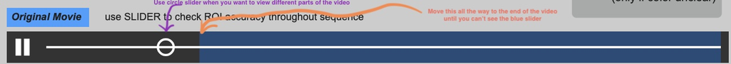

## Step 3: Set ROIs

In order to draw each ROI, you will have to first select the ROI size. I typically use the “big” size (occasionally I’ll use medium, but use whatever you feel comfortable with) for all ROI setting.

After selecting the size, you can click on one of the ROIs to start drawing. The `red` light indicates the ROI that is currently active, so that’s the one that you’ll be drawing with. Also, once you click on one of the ROIs, the `green` light will turn on, which means that the ROI has been turned on and the software will collect data for that ROI.

It’s *very* important to set each ROI in this exact way every single time:

`ROI 1`: patient head

`ROI 2`: patient body

`ROI 3`: therapist head

`ROI 4`: therapist body

Your end result should look something like this:

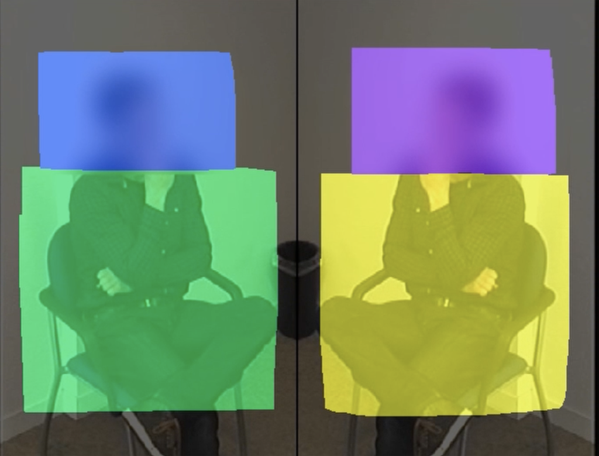

ROI layout

## Step 4: Check ROIs & Adjust as Needed

Before moving on, check that your ROI (e.g., ROI 1) covers the appropriate region (e.g., ROI 1 should cover the patient’s head for the majority of the video). Check at least *10* different time points in the video. Adjust the ROIs as needed based on movement in the video (e.g., if the patient’s head moves out of your original ROI, make the ROI larger, etc.).

Try your best to look through the video at different time points and draw the best ROIs that cover each region of the body for the majority of the video (it won’t be perfect and that’s okay).

## Step 5: Take a screenshot of the ROIs

Use the Snipping Tool to take a screenshot of the ROIs you set and save the screenshot in `DAPPeR/MEA/Phase_2/screenshots`, in the projects folder. Name the screenshot `patientID_therapistID_sessionnumber`. For example, “2001_2010_05” for patient ID 2001, therapist ID 2010, and session number 5.

## Step 6: Set threshold

Set the threshold to `15` using the slider or by typing it in.

## Step 7: Clear .txt and check to make sure it’s cleared!

Before you start the MEA, please make sure to click on “clear data”. Then, click on “open data” to review the .txt file to make sure it’s completely cleared. This is *super* important before you start the MEA. So please double check!!

## Step 8: Start MEA

Click “Start MEA”. You’ll know it’s done when the “total frames” matches the “elapsed frames”. Each 50 minute video should take about 20 minutes to analyze.

## Step 9: Save Results

Once the MEA is complete, please remember to click “save TXT” and save the file in the `DAPPeR/MEA/Phase_2/raw` folder on the projects server. Please name the .txt file as `patientID_SessionNumber`. For example, “2001_2010_05” for patient ID 2001, therapist ID 2010, and session number 5. Also, when you rename the file, add the extension `.txt`. So type in exactly “2001_2010_05.txt” in this case.

## Step 10: Fill out the rest of the spreadsheet

Open the .txt and scroll all the way to the bottom of the data. Select the last row to get the number of frames.

Before moving on to the next video, open Task Manager and end the MEA application task. This will ensure that we don’t have any “leftover data” in the .txt file. And it’s easier to draw the ROIs if you just refresh the software.

## Overview:

```
flowchart TD
  A(Read in video file) --> B(Prep for setting ROIs)
  B --> C(Set ROIs)
  C --> D(Check ROIs & adjust as needed)
  D --> E(Screenshot ROIs)
  E --> F(Set threshold)
  F --> G(Clear .txt and check it)
  G --> H(Start MEA Processing)
  H --> I(Save Results)
```